# Praca domowa 2

Karol Kacprzak

## Dane

Dane wykorzystane w Pracy domowej 2 opisują wycenę nieruchmości. Każda obserwacja jest pewną nieruchmością, która posiada informacje takie jak powierzchnia, liczba pokoi, liczba łazienek i wiele więcj. Opis wszystkich kolumn w pliku `README.md`.

## Zadanie 1

Jak wygląda rozkład ceny nieruchomości w poszczególnych kodach pocztowych na przestrzeni lat? Rozważamy kody pocztowe, które mają więcej niż 280 posiadłości.

```r
# Tu umieść kod do wygenerowania odpowiedzi do zadania.
df1<-df %>%
  mutate(year=as.numeric(substring(date,1,4))) %>%
  group_by(zipcode) %>%
  summarise(year,price,count=n()) %>%
  filter(count>280)
```

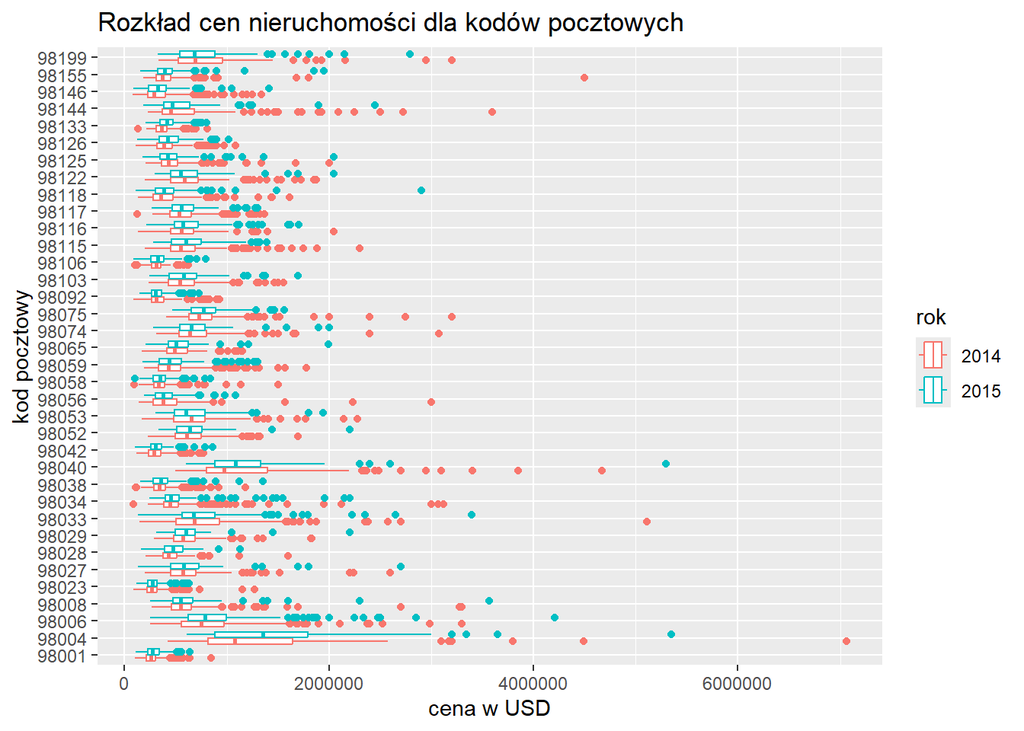

```r
options(scipen=999)

ggplot(data=df1,mapping = aes(x=price,y=as.factor(zipcode),color=as.factor(year)))+
  geom_boxplot()+
  labs(title="Rozkład cen nieruchomości dla kodów pocztowych",
       y= "kod pocztowy",
       x="cena w USD",
       color="rok")
```

## Zadanie 2

Czy jest różnica w rozkładzie ceny nierchomości od powierzchni mieszkalnej uwzględniając podział na nieruchomości z piwnicą i bez?

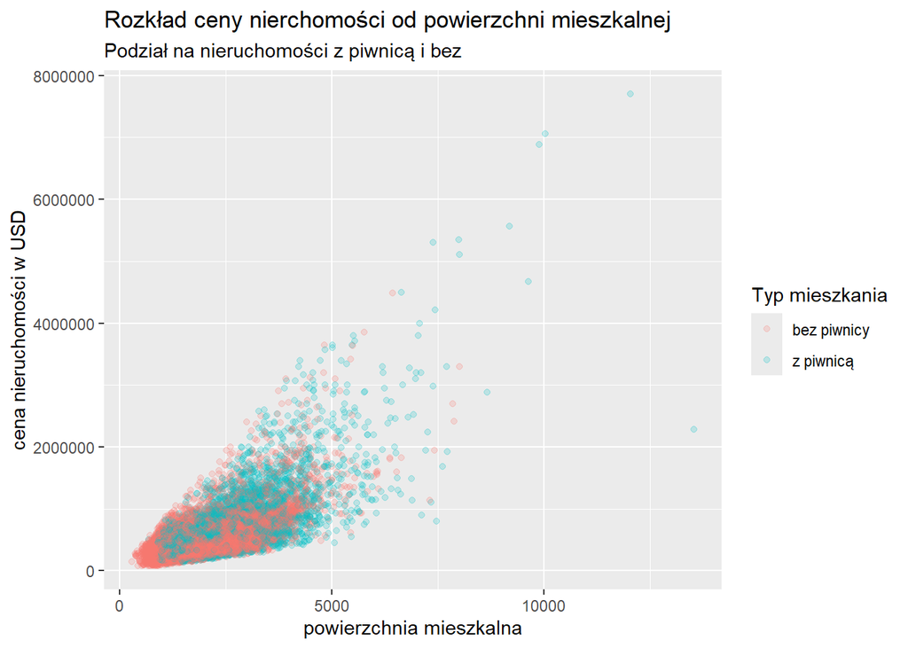

```r
# Tu umieść kod do wygenerowania odpowiedzi do zadania.
df2<-df %>%
  mutate(has_basement= case_when(
         sqft_basement>0 ~"z piwnicą",
         .default = "bez piwnicy"))



ggplot(df2,mapping = aes(x=sqft_living, y=price, color=as.factor(has_basement)))+
  geom_point(alpha=0.2)+
  labs(title ="Rozkład ceny nierchomości od powierzchni mieszkalnej",
       subtitle = "Podział na nieruchomości z piwnicą i bez",
       y="cena nieruchomości w USD",
       x="powierzchnia mieszkalna",
       color="Typ mieszkania")
```

**Komentarz: Nieruchomości posiadające piwnice mają częściej większą powierzchnię, a przy zbliżonej powierzchni mają wyższą ceną od nieruchomości bez piwnic**

## Zadanie 3

Jaka jest zależność pomiędzy jakością wykończenia nieruchomości a liczbą pięter?

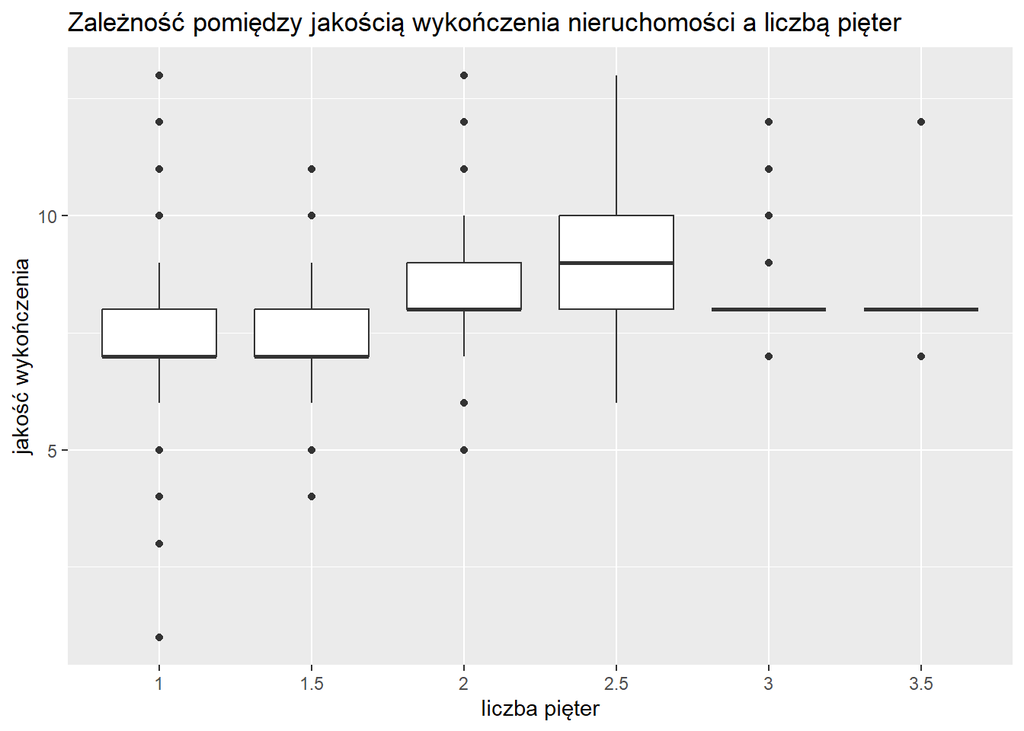

```r
# Tu umieść kod do wygenerowania odpowiedzi do zadania.

ggplot(df,mapping = aes(x=as.factor(floors),y=grade))+
  geom_boxplot()+
  labs(title ="Zależność pomiędzy jakością wykończenia nieruchomości a liczbą pięter",
       y="jakość wykończenia",
       x="liczba pięter")
```

**Komentarz: mediana jakości wykończenia rośnie wraz ze wzrostem liczby pięter nieruchomości, następni już maleje**

## Zadanie 4

Jaka jest zależność między powierzchnią mieszkalną nieruchomości a powierzchnią gruntu w podziale na liczbę sypialni?

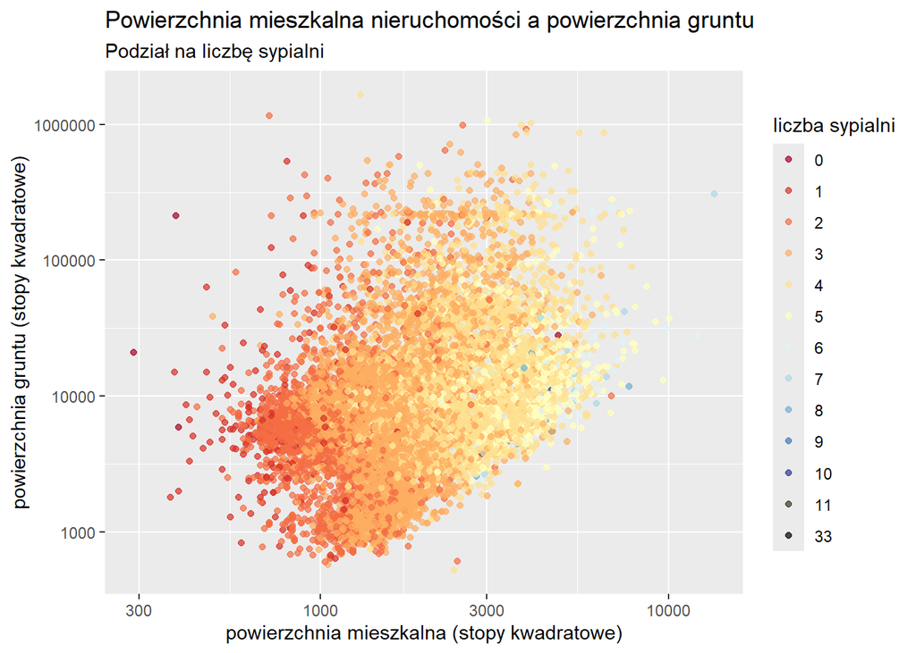

```r
# Tu umieść kod do wygenerowania odpowiedzi do zadania.
ggplot(df,mapping = aes(x=sqft_living,y=sqft_lot,color=as.factor(bedrooms)))+
  geom_point(alpha=0.7)+
  labs(title ="Powierzchnia mieszkalna nieruchomości a powierzchnia gruntu",
       subtitle = "Podział na liczbę sypialni",
       y="powierzchnia gruntu (stopy kwadratowe)",
       x="powierzchnia mieszkalna (stopy kwadratowe)",
       color="liczba sypialni")+
  scale_x_log10()+
  scale_y_log10()+
  scale_color_manual(values = c(
    "0" = "#a50026", "1" = "#d73027", "2" = "#f46d43",
    "3" = "#fdae61", "4" = "#fee090", "5" = "#ffffbf",
    "6" = "#e0f3f8", "7" = "#abd9e9", "8" = "#74add1",
    "9" = "#4575b4", "10" = "#313695", "11" = "#363626",
    "33" = "#000000"))
```

**Komentarz: (skala logarytmiczna dla lepszej przejrzystości). Ze wzrostem powierzchni mieszkalnej rośnie też minimalna i średnia powierzchnia gruntu. Zdecydowana większość mieszkań ma od 2 do 5 sypialni, wraz z powierzchnią mieszkalną rośnie liczba sypialni (zgodnie z tym czego można było oczekiwać), istnieją nieruchomości o większej powierzchni mieszkalnej niż powierzchnia gruntu (na pewno mają >1 piętra), ale jest ich niewiele**

## Zadanie 5

Rozważmy tylko nieruchomości, które miały remont. W której dekadzie było najwięcej przeprowadzonych remontów? Czy w poszczególnych dekadach jest porównywalny procent nieruchmości dla każdej wartości miary jakości i wykończenia nieruchomości?

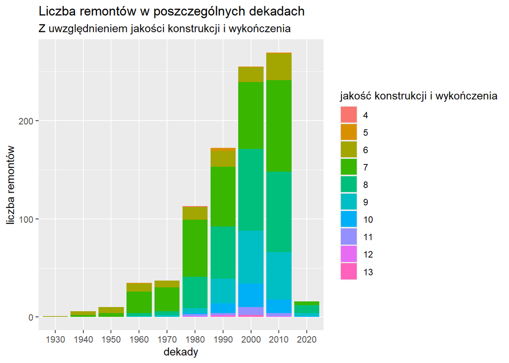

```r
# Tu umieść kod do wygenerowania odpowiedzi do zadania.
df5<-df %>%
  filter(yr_renovated!=0) %>%
  mutate(decade=round(yr_renovated,digits=-1)) #%>%

ggplot(df5,mapping = aes(x=as.factor(decade),fill=as.factor(grade)))+
  geom_bar()+
  labs(title ="Liczba remontów w poszczególnych dekadach",
       subtitle = "Z uwzględnieniem jakości konstrukcji i wykończenia",
       y="liczba remontów",
       x="dekady",
       fill="jakość konstrukcji i wykończenia")
```

## Zadanie 6

Jak prezentuje się wartość minimalna, średnia i maksymalna ceny nieruchmości w podziele na rok budowy nieruchomości.

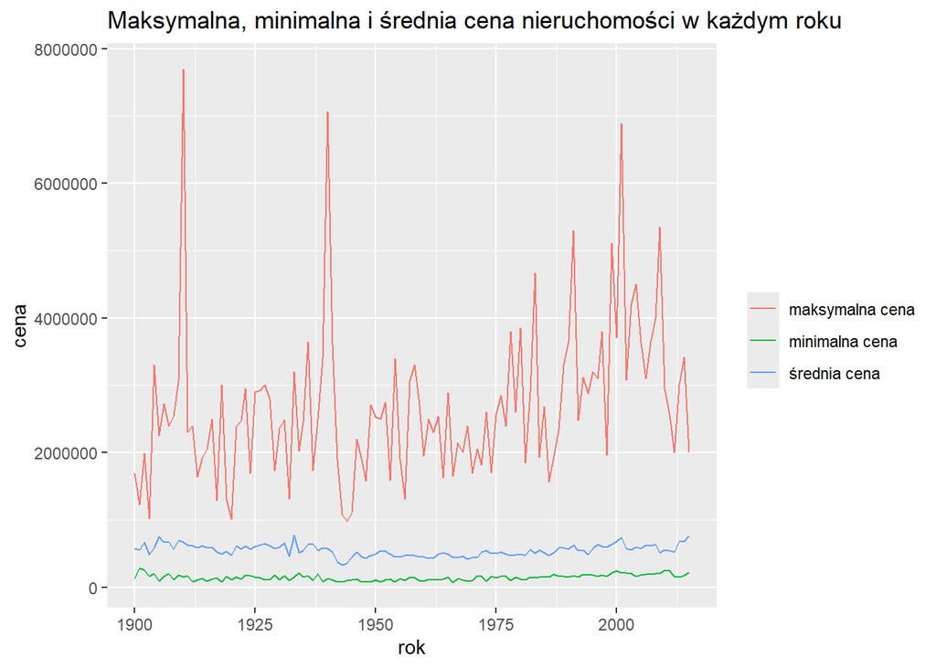

```r
# Tu umieść kod do wygenerowania odpowiedzi do zadania.
df6<-df %>%
  group_by(yr_built) %>%
  summarise(mean=mean(price),max=max(price),min=min(price))

ggplot(df6,mapping = aes(x=yr_built))+
    geom_line(aes(y=mean,color="średnia cena"))+
    geom_line(aes(y=max,color="maksymalna cena"))+
    geom_line(aes(y=min,color="minimalna cena"))+
    labs(title ="Maksymalna, minimalna i średnia cena nieruchomości w każdym roku",
       y="cena",
       x="rok",
       color="")
```

**Komentarz: Maksymalna cena jest bardzo zmienna, średnia i minimalna cena przez cały okres mają w przybliżeniu stałe poziomy**